# Survival Analysis with Machine Learning on PBC dataset

Rony Zafrir

# Introduction

In this project, we analyze survival data from a clinical study on Primary Biliary Cirrhosis (PBC), a chronic liver disease. Our objective is to compare traditional survival models, such as the Cox Proportional Hazards model, with modern machine learning approaches, including Random Survival Forests and a deep learning-based survival model (DeepHit). The dataset includes time-to-event information (death or liver transplant) and various clinical covariates for over 300 patients. We assess model performance using standard metrics such as the Concordance Index (C-index) and Integrated Brier Score (IBS). Our analysis revealed that the treatment variable (D-penicillamine vs. placebo) did not have a significant impact on patient survival, aligning with clinical findings that questioned the drug’s efficacy. Also, Random Survival Forests achieved the best overall performance, with the lowest Integrated Brier Score and the highest C-index, suggesting strong predictive ability and good calibration.

# The Primiary Biliary Cirrhosis Dataset

This clinical dataset is derived from a ten-year-study conducted to investigate the nature and treatment outcomes of primary biliary cirrhosis, a chronic liver disease. Patients were treated with D-penicillamine or placebo. The dataset contains various clinical and laboratory measurements, as well as information on time to death or liver transplant, along with censoring status.

```
##
##  Dimensions of the dataset:  312 20
##  Number of rows with missing values:  36
##  Number of columns with missing values:  4
##  Columns with missing values:  chol, copper, trig, platelet
##  Total number of missing values:  64
##  Numeric variables:  time, age, bili, chol, albumin, copper, alk_phos, sgot, trig, platelet, protime
##  Categorical variables:  status, drug, sex, ascites, hepatomegaly, spiders, edema, stage
```

|  | id | time | status | drug | age | sex | ascites | hepatomegaly | spiders | edema | bili | chol | albumin | copper | alk_phos | sgot | trig | platelet | protime | stage |
| --- | --- | --- | --- | --- | --- | --- | --- | --- | --- | --- | --- | --- | --- | --- | --- | --- | --- | --- | --- | --- |
| 1 | 1 | 400 | 2 | 1 | 21464 | 1 | 1 | 1 | 1 | 1.0 | 14.5 | 261 | 2.60 | 156 | 1718.0 | 137.95 | 172 | 190 | 12.2 | 4 |
| 2 | 2 | 4500 | 0 | 1 | 20617 | 1 | 0 | 1 | 1 | 0.0 | 1.1 | 302 | 4.14 | 54 | 7394.8 | 113.52 | 88 | 221 | 10.6 | 3 |
| 3 | 3 | 1012 | 2 | 1 | 25594 | 0 | 0 | 0 | 0 | 0.5 | 1.4 | 176 | 3.48 | 210 | 516.0 | 96.10 | 55 | 151 | 12.0 | 4 |
| 4 | 4 | 1925 | 2 | 1 | 19994 | 1 | 0 | 1 | 1 | 0.5 | 1.8 | 244 | 2.54 | 64 | 6121.8 | 60.63 | 92 | 183 | 10.3 | 4 |
| 5 | 5 | 1504 | 1 | 2 | 13918 | 1 | 0 | 1 | 1 | 0.0 | 3.4 | 279 | 3.53 | 143 | 671.0 | 113.15 | 72 | 136 | 10.9 | 3 |
| 6 | 6 | 2503 | 2 | 2 | 24201 | 1 | 0 | 1 | 0 | 0.0 | 0.8 | 248 | 3.98 | 50 | 944.0 | 93.00 | 63 | NA | 11.0 | 3 |

# Variables description:

id: case number time: number of days until censoring, death or liver transplant status: 0=alive, 1=transplanted, 2=dead drug: 1= D-penicillamine (treatment), 2=placebo age: age in days, at registration sex: 0=male, 1=female ascites: 0=no, 1=yes hepatomegaly: 0=no, 1=yes spiders: 0=no, 1=yes edema: 0=no, 0.5 = edema present without diuretics, 1 = edema despite diuretic therapy bili: bilirubin results in mg/dl chol: cholesterol results in mg/dl albumin: albumin results in mg/dl copper: urine copper in ug/day alk_phos: alkaline phosphatase results in U/liter sgot: SGOT results in U/ml trig: triglycerides results in mg/dl platelet: platelets per cubic ml / 1000 protime: prothrombin time in seconds stage: histologic stage of disease (1 = early, 2 = mild, 3 = advanced, 4 = late)}

# Descriptive Statistics

## Status Distribution

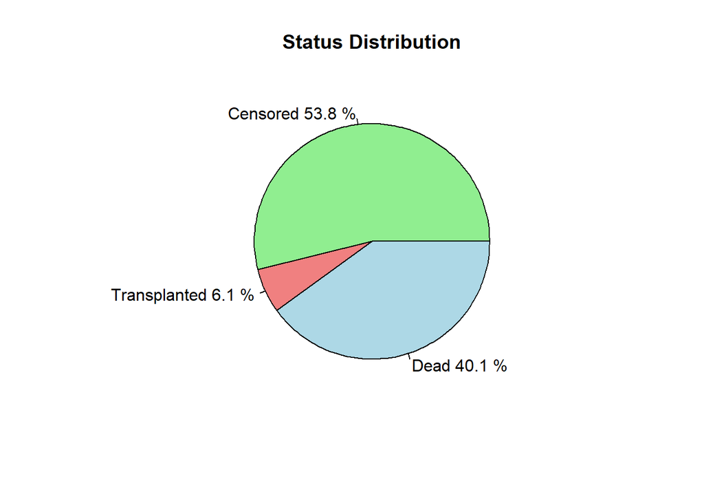

## Stage Distribution

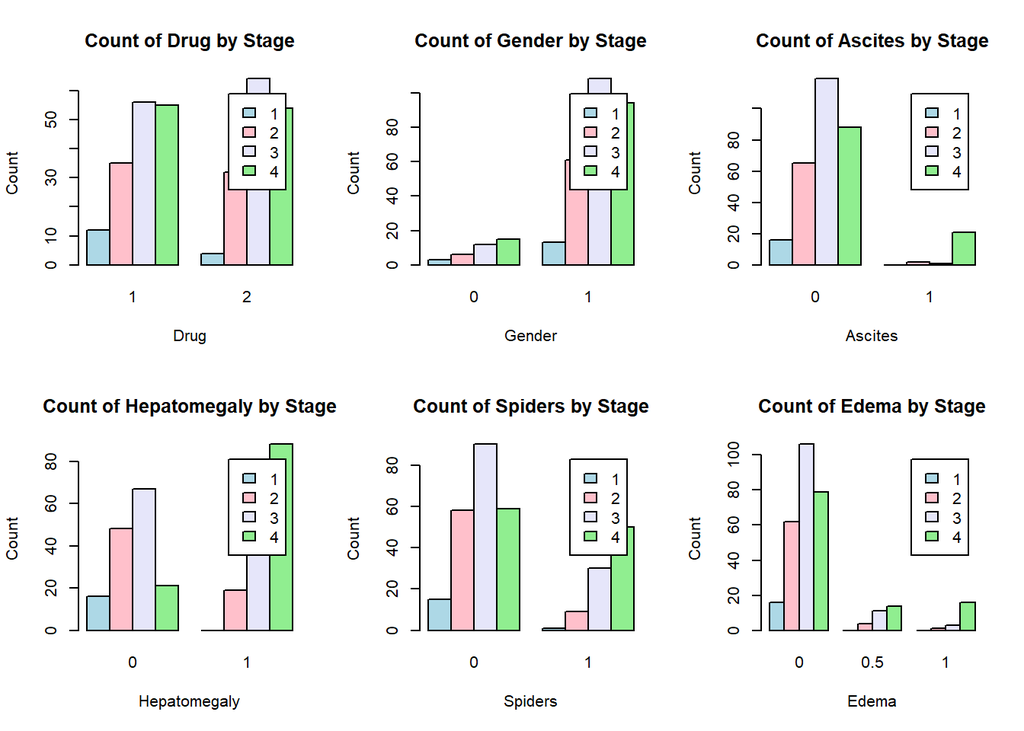

## Correlation Matrix Plot

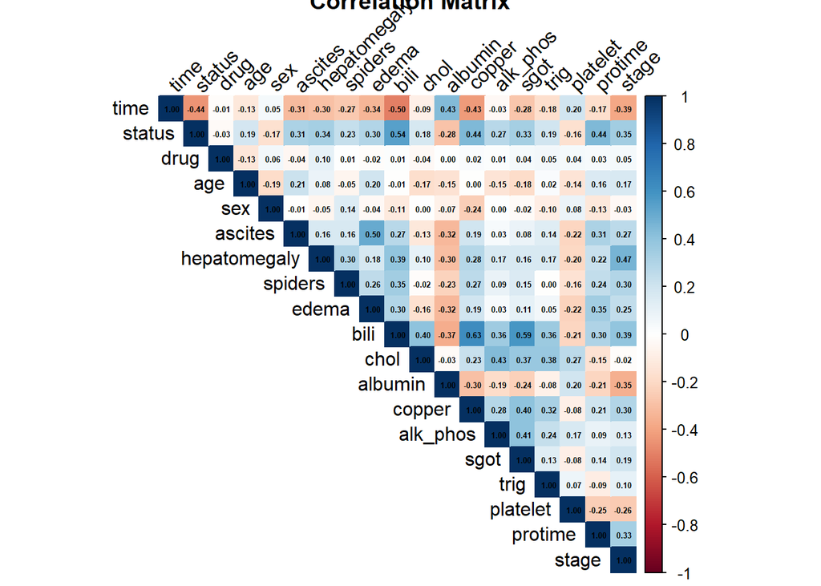

It seems that the covariates are not highly correlated with each other, which is a good sign for our analysis.

## Histograms

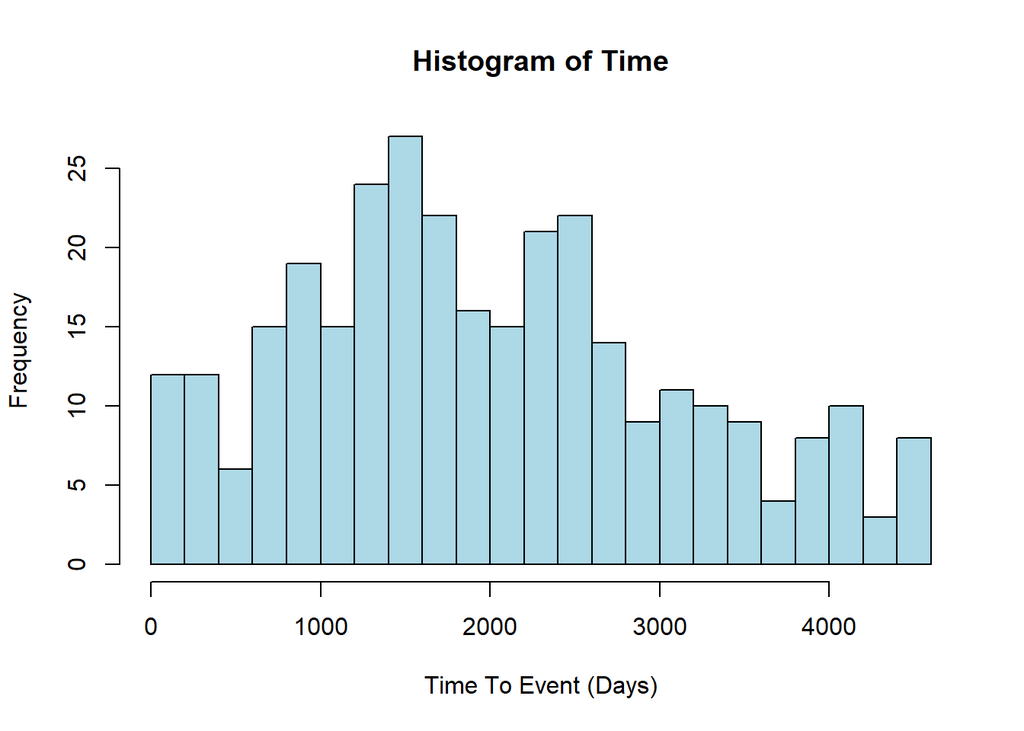

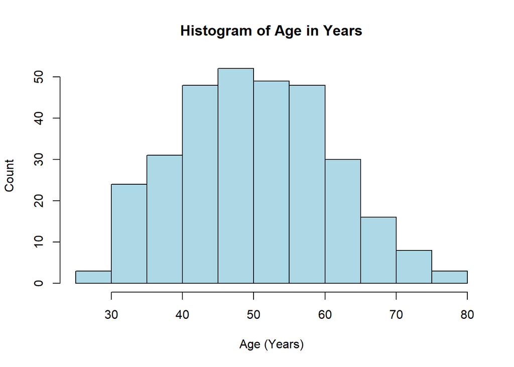

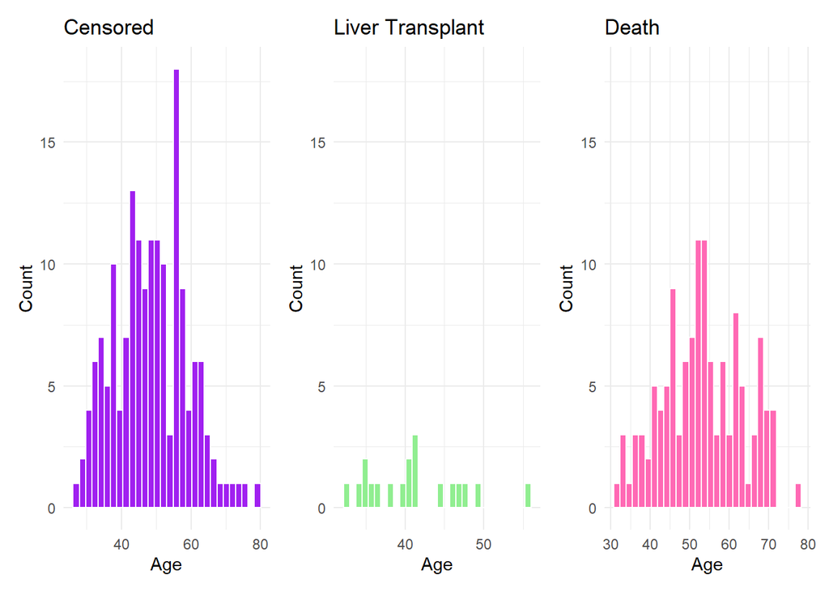

## Box-Plots

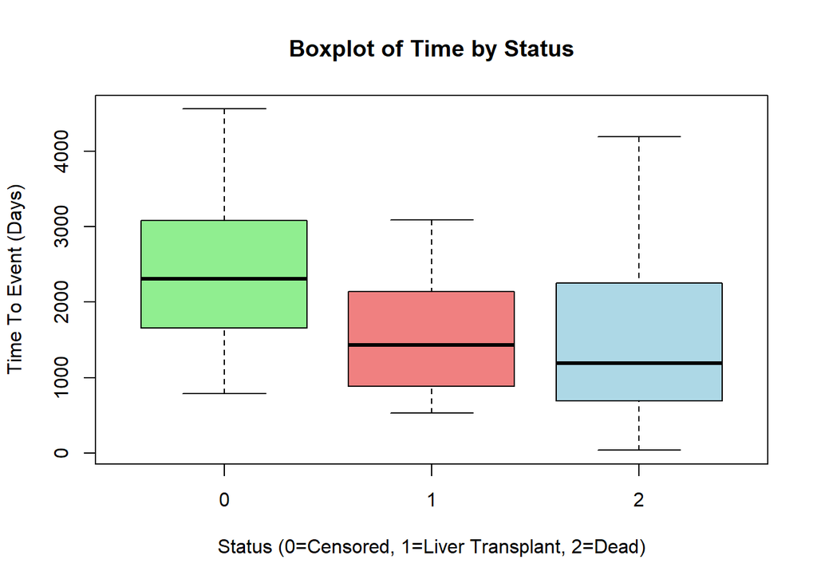

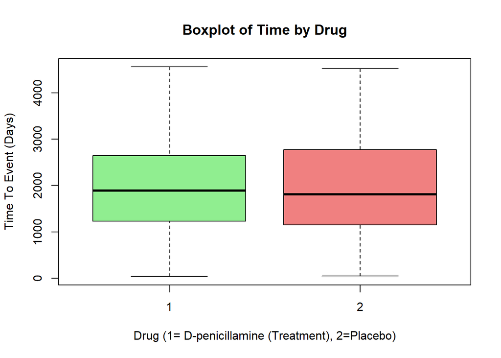

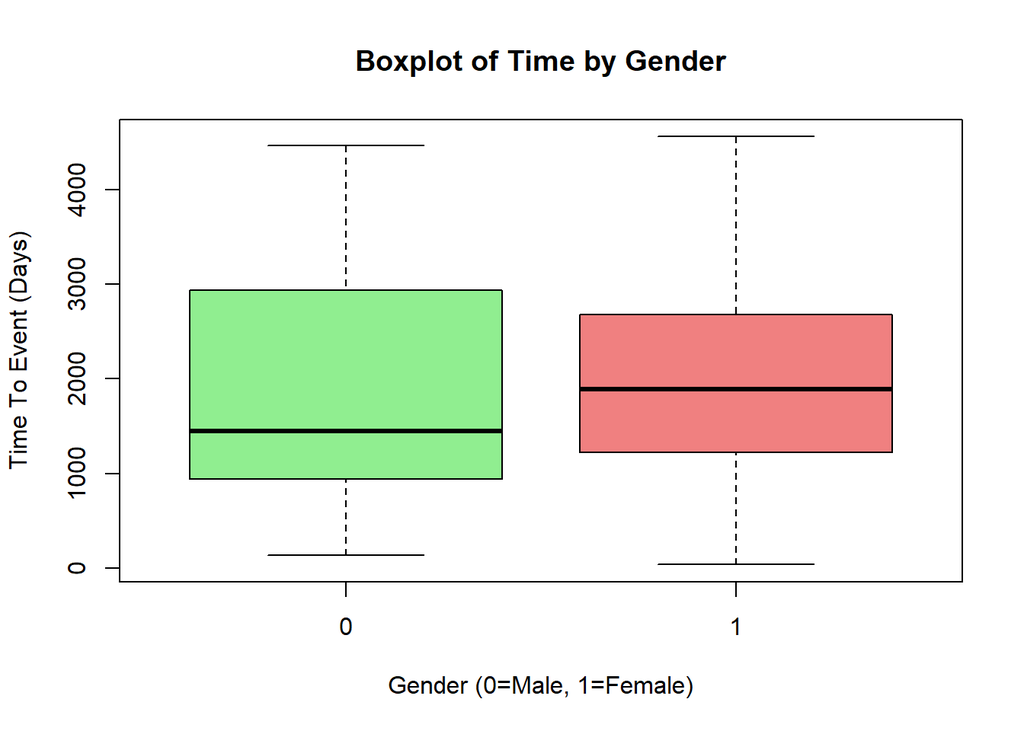

# Cox Proportional Hazards Model

The Cox proportional hazards model is a semi-parametric regression model, used to examine the effect of multiple variables on the time to event. The model doesn’t require specification of the baseline hazard function $h_0(t)$.

## Death as the Event of Interest

### Model

```
## Call:
## coxph(formula = Surv(time, status_death) ~ factor(drug) + age_years +
##     sex + ascites + hepatomegaly + spiders + factor(edema) +
##     bili + chol + albumin + copper + alk_phos + sgot + trig +
##     platelet + protime + factor(stage), data = data, na.action = na.exclude)
##
##   n= 276, number of events= 111
##    (36 observations deleted due to missingness)
##
##                        coef  exp(coef)   se(coef)      z Pr(>|z|)
## factor(drug)2    -1.765e-01  8.382e-01  2.189e-01 -0.806  0.42003
## age_years         2.889e-02  1.029e+00  1.164e-02  2.483  0.01304 *
## sex              -3.757e-01  6.868e-01  3.111e-01 -1.208  0.22720
## ascites           5.899e-04  1.001e+00  3.951e-01  0.001  0.99881
## hepatomegaly      5.648e-02  1.058e+00  2.565e-01  0.220  0.82575
## spiders           7.011e-02  1.073e+00  2.491e-01  0.281  0.77839
## factor(edema)0.5  2.436e-01  1.276e+00  3.354e-01  0.726  0.46764
## factor(edema)1    1.146e+00  3.146e+00  4.166e-01  2.751  0.00595 **
## bili              8.014e-02  1.083e+00  2.628e-02  3.050  0.00229 **
## chol              4.731e-04  1.000e+00  4.534e-04  1.043  0.29675
## albumin          -7.496e-01  4.725e-01  3.104e-01 -2.415  0.01572 *
## copper            2.442e-03  1.002e+00  1.171e-03  2.087  0.03693 *
## alk_phos          5.228e-07  1.000e+00  4.066e-05  0.013  0.98974
## sgot              3.710e-03  1.004e+00  1.992e-03  1.863  0.06247 .
## trig             -5.177e-04  9.995e-01  1.436e-03 -0.361  0.71846
## platelet          8.410e-04  1.001e+00  1.189e-03  0.707  0.47929
## protime           2.763e-01  1.318e+00  1.167e-01  2.367  0.01793 *
## factor(stage)2    1.406e+00  4.081e+00  1.080e+00  1.302  0.19288
## factor(stage)3    1.683e+00  5.380e+00  1.052e+00  1.600  0.10968
## factor(stage)4    2.119e+00  8.325e+00  1.067e+00  1.985  0.04711 *
## ---
## Signif. codes:  0 '***' 0.001 '**' 0.01 '*' 0.05 '.' 0.1 ' ' 1
##
##                  exp(coef) exp(-coef) lower .95 upper .95
## factor(drug)2       0.8382     1.1930    0.5458    1.2872
## age_years           1.0293     0.9715    1.0061    1.0531
## sex                 0.6868     1.4560    0.3732    1.2637
## ascites             1.0006     0.9994    0.4613    2.1704
## hepatomegaly        1.0581     0.9451    0.6400    1.7494
## spiders             1.0726     0.9323    0.6582    1.7479
## factor(edema)0.5    1.2759     0.7838    0.6611    2.4623
## factor(edema)1      3.1456     0.3179    1.3901    7.1178
## bili                1.0834     0.9230    1.0291    1.1407
## chol                1.0005     0.9995    0.9996    1.0014
## albumin             0.4725     2.1162    0.2572    0.8682
## copper              1.0024     0.9976    1.0001    1.0047
## alk_phos            1.0000     1.0000    0.9999    1.0001
## sgot                1.0037     0.9963    0.9998    1.0076
## trig                0.9995     1.0005    0.9967    1.0023
## platelet            1.0008     0.9992    0.9985    1.0032
## protime             1.3183     0.7586    1.0487    1.6572
## factor(stage)2      4.0811     0.2450    0.4914   33.8956
## factor(stage)3      5.3797     0.1859    0.6845   42.2793
## factor(stage)4      8.3253     0.1201    1.0274   67.4610
##
## Concordance= 0.848  (se = 0.018 )
## Likelihood ratio test= 169.7  on 20 df,   p=<2e-16
## Wald test            = 175  on 20 df,   p=<2e-16
## Score (logrank) test = 295.6  on 20 df,   p=<2e-16
```

### Model Results with Benjamini-Hochberg Adjustment for Multiple Comparisons

[output not shown]

[output cut: 10 more lines]

After applying the Benjamini-Hochberg method for multiple comparisons, the ‘bili’ variable is significant at the 0.05 level. Other variables that are almost-significant: age in years, edema (group 1), albumin and protime. Refitting cox model for death with only these variables.

### Refit Cox Model for Death with Selected Variables

```
## Call:
## coxph(formula = Surv(time, status_death) ~ age_years + factor(edema) +
##     bili + albumin + protime, data = data, na.action = na.exclude,
##     x = TRUE, y = TRUE)
##
##   n= 312, number of events= 125
##
##                       coef exp(coef)  se(coef)      z Pr(>|z|)
## age_years         0.034831  1.035445  0.009323  3.736 0.000187 ***
## factor(edema)0.5  0.015929  1.016057  0.281241  0.057 0.954832
## factor(edema)1    1.006120  2.734970  0.313723  3.207 0.001341 **
## bili              0.119563  1.127004  0.015494  7.717 1.19e-14 ***
## albumin          -1.204722  0.299775  0.235038 -5.126 2.97e-07 ***
## protime           0.258014  1.294357  0.074382  3.469 0.000523 ***
## ---
## Signif. codes:  0 '***' 0.001 '**' 0.01 '*' 0.05 '.' 0.1 ' ' 1
##
##                  exp(coef) exp(-coef) lower .95 upper .95
## age_years           1.0354     0.9658    1.0167    1.0545
## factor(edema)0.5    1.0161     0.9842    0.5855    1.7632
## factor(edema)1      2.7350     0.3656    1.4788    5.0582
## bili                1.1270     0.8873    1.0933    1.1618
## albumin             0.2998     3.3358    0.1891    0.4752
## protime             1.2944     0.7726    1.1188    1.4975
##
## Concordance= 0.828  (se = 0.02 )
## Likelihood ratio test= 166.8  on 6 df,   p=<2e-16
## Wald test            = 188.9  on 6 df,   p=<2e-16
## Score (logrank) test = 309.6  on 6 df,   p=<2e-16
```

### Final Model Results with Benjamini-Hochberg Adjustment for Multiple Comparisons

[output not shown]

## Integrated Brier Score for Cox Model

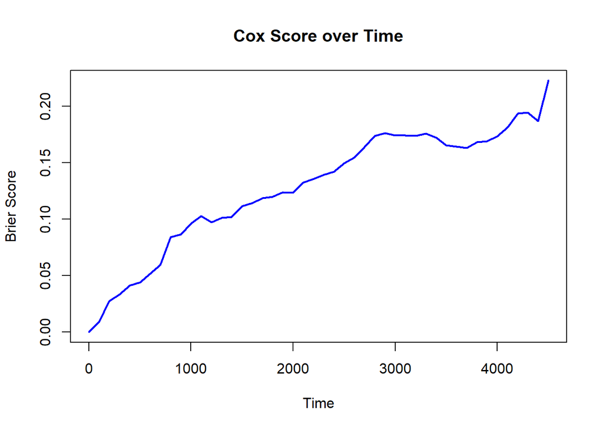

exp(coef) provides the hazard ratio for a one unit increase in the predictor variable, holding all other variables constant. For each additional year of age, the hazard of death increases by 3.5%. Patients with edema (edema = 1) have a significantly higher risk of death (173.5%) compared to those without edema (edema = 0). This makes sense, as edema is a marker of advanced liver dysfunction. For each additional mg/dL of bilirubin (a waste product made when the body breaks down old red blood cells), the hazard of death increases by 12.7%. For each additional gm/dL of albumin (a protein in the blood that helps carry waste, and keeps fluid from leaking out of blood vessels), the hazard of death decreases by 70%. For each additional second of prothrombin time (how long it takes blood to clot), the hazard of death increases by 30%.

## Liver Transplant as the Event of Interest

### Model

```
## Warning in coxph.fit(X, Y, istrat, offset, init, control, weights = weights, :
## Loglik converged before variable 4,8,18,19,20 ; coefficient may be infinite.
```

```
## Call:
## coxph(formula = Surv(time, status_transplant) ~ factor(drug) +
##     age_years + sex + ascites + spiders + hepatomegaly + factor(edema) +
##     bili + chol + albumin + copper + alk_phos + sgot + trig +
##     platelet + protime + factor(stage), data = data, na.action = na.exclude)
##
##   n= 276, number of events= 18
##    (36 observations deleted due to missingness)
##
##                        coef  exp(coef)   se(coef)      z Pr(>|z|)
## factor(drug)2    -5.109e-01  6.000e-01  5.577e-01 -0.916 0.359705
## age_years        -1.308e-01  8.774e-01  3.423e-02 -3.820 0.000133 ***
## sex              -1.081e+00  3.392e-01  9.324e-01 -1.160 0.246178
## ascites          -2.149e+01  4.653e-10  1.440e+04 -0.001 0.998809
## spiders          -8.608e-01  4.228e-01  6.765e-01 -1.273 0.203184
## hepatomegaly      1.033e+00  2.809e+00  6.729e-01  1.535 0.124829
## factor(edema)0.5  1.521e+00  4.577e+00  8.913e-01  1.707 0.087911 .
## factor(edema)1   -1.744e+01  2.661e-08  1.861e+04 -0.001 0.999252
## bili              6.837e-02  1.071e+00  9.134e-02  0.748 0.454179
## chol              1.282e-03  1.001e+00  1.278e-03  1.003 0.315797
## albumin          -1.277e+00  2.788e-01  1.029e+00 -1.241 0.214451
## copper            2.143e-03  1.002e+00  2.970e-03  0.722 0.470451
## alk_phos         -7.453e-04  9.993e-01  4.416e-04 -1.688 0.091461 .
## sgot             -9.642e-04  9.990e-01  5.314e-03 -0.181 0.856025
## trig              3.406e-03  1.003e+00  4.651e-03  0.732 0.463890
## platelet          4.780e-03  1.005e+00  3.278e-03  1.458 0.144712
## protime          -4.234e-01  6.548e-01  4.413e-01 -0.959 0.337327
## factor(stage)2    1.693e+01  2.257e+07  5.855e+03  0.003 0.997692
## factor(stage)3    1.776e+01  5.155e+07  5.855e+03  0.003 0.997580
## factor(stage)4    1.883e+01  1.504e+08  5.855e+03  0.003 0.997434
## ---
## Signif. codes:  0 '***' 0.001 '**' 0.01 '*' 0.05 '.' 0.1 ' ' 1
##
##                  exp(coef) exp(-coef) lower .95 upper .95
## factor(drug)2    6.000e-01  1.667e+00   0.20109    1.7902
## age_years        8.774e-01  1.140e+00   0.82049    0.9383
## sex              3.392e-01  2.948e+00   0.05455    2.1089
## ascites          4.653e-10  2.149e+09   0.00000       Inf
## spiders          4.228e-01  2.365e+00   0.11230    1.5920
## hepatomegaly     2.809e+00  3.560e-01   0.75121   10.5018
## factor(edema)0.5 4.577e+00  2.185e-01   0.79779   26.2615
## factor(edema)1   2.661e-08  3.759e+07   0.00000       Inf
## bili             1.071e+00  9.339e-01   0.89524    1.2807
## chol             1.001e+00  9.987e-01   0.99878    1.0038
## albumin          2.788e-01  3.587e+00   0.03711    2.0945
## copper           1.002e+00  9.979e-01   0.99633    1.0080
## alk_phos         9.993e-01  1.001e+00   0.99839    1.0001
## sgot             9.990e-01  1.001e+00   0.98869    1.0095
## trig             1.003e+00  9.966e-01   0.99431    1.0126
## platelet         1.005e+00  9.952e-01   0.99836    1.0113
## protime          6.548e-01  1.527e+00   0.27575    1.5550
## factor(stage)2   2.257e+07  4.431e-08   0.00000       Inf
## factor(stage)3   5.155e+07  1.940e-08   0.00000       Inf
## factor(stage)4   1.504e+08  6.651e-09   0.00000       Inf
##
## Concordance= 0.882  (se = 0.028 )
## Likelihood ratio test= 41.74  on 20 df,   p=0.003
## Wald test            = 19.85  on 20 df,   p=0.5
## Score (logrank) test = 38.72  on 20 df,   p=0.007
```

A note regarding the warning, when status=1: 1. ascites=0 for all the observations. 2. edema$!=$ 1 for all the observations. 3. stage $!=$ 1 for all the observations, hence there’s no baseline to compare to for stages 2,3,4. The meaning is that the model cannot estimate a meaningful hazard ratio for ascites and edema, as the variation is 0 in these variables among event cases. Therefore, we cannot draw reliable conclusions about the effect of these variables on the hazard of transplant in this model.

### Model Results with Benjamini-Hochberg Adjustment for Multiple Comparisons

[output not shown]

[output cut: 10 more lines]

After applying the Benjamini-Hochberg method for multiple comparisons, the age in years variable is significant at the 0.05 level. Refitting cox model for transplant with only this variables.

### Refit Cox Model for Transplant with Selected Variables

```
## Call:
## coxph(formula = Surv(time, status_transplant) ~ age_years, data = data)
##
##   n= 312, number of events= 19
##
##               coef exp(coef) se(coef)      z Pr(>|z|)
## age_years -0.09184   0.91225  0.02710 -3.389 0.000702 ***
## ---
## Signif. codes:  0 '***' 0.001 '**' 0.01 '*' 0.05 '.' 0.1 ' ' 1
##
##           exp(coef) exp(-coef) lower .95 upper .95
## age_years    0.9122      1.096    0.8651     0.962
##
## Concordance= 0.728  (se = 0.049 )
## Likelihood ratio test= 13.25  on 1 df,   p=3e-04
## Wald test            = 11.48  on 1 df,   p=7e-04
## Score (logrank) test = 12.21  on 1 df,   p=5e-04
```

Age in years was significant, for each additional year of age, the ‘hazard’ of receiving a transplant decreases by 9%. (exp(coef) is the hazard ratio = 0.91225). This means that older patients are less likely to receive a transplant compared to younger patients. We must take into consideration that the model is not very informative, as it is based on merely 19 observations.

## Comparison between Cox Models

The Cox proportional hazards model for death is more informative than the model for transplant: For the death model 0.828, for the transplant model 0.728. The death model has better discrimination (82.8%) compared to transplant (72.8%). For the death model 166.8 on 6 df, for the transplant model 13.25 on 1 df. Both models are significant, but the death model explains much more variation. For the death model 188.9 on 6 df, for the transplant model 11.48 on 1 df. For the death model 309.6 on 6 df, for the transplant model 12.21 on 1 df. Strong statistical evidence for both, but death model clearly outperforms.

In addition, the hazard ratio for death increases by 3.5% for each additional year of age, while the hazard ratio for transplant decreases by 9% for each additional year of age. These results were expected, as the death event is a lot more common than the transplant event in this dataset (111 observations for death, 19 for transplant).

# Models Estimating Cummulative Incidence Function (CIF)

The Cumulative Incidence Function (CIF) shows the probability that a specific event (death) has happened by a certain time, while accounting for the fact that once a competing event occurs (liver transplant), the primary event can no longer happen.

## CIF by Stage

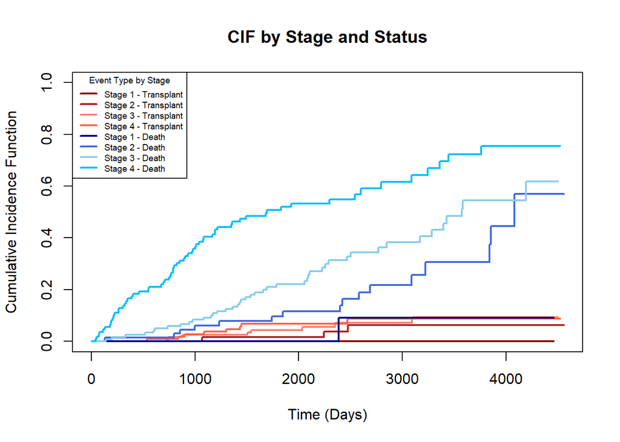

## CIF by Drug

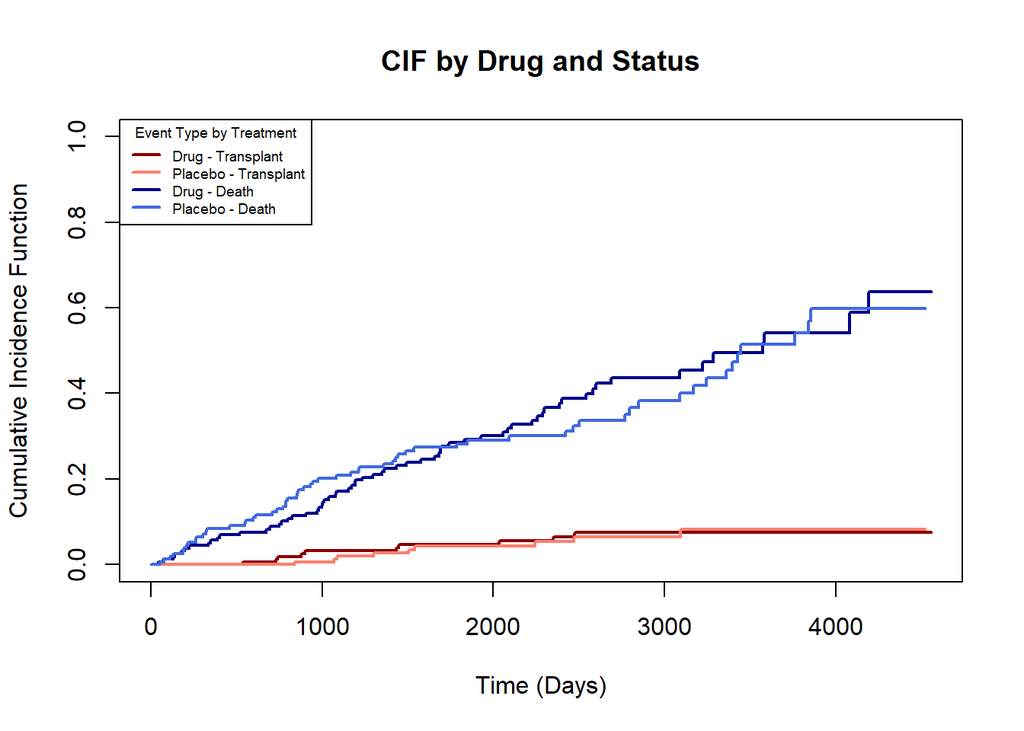

- Death remains the dominant event over transplant, regardless of group. - The CIFs of Drug and Placebo death are comparable and intersect, so there’s no strong evidence of a consistent mortality benefit.

## CIF by Age Groups

```
## 103 cases omitted due to missing values
```

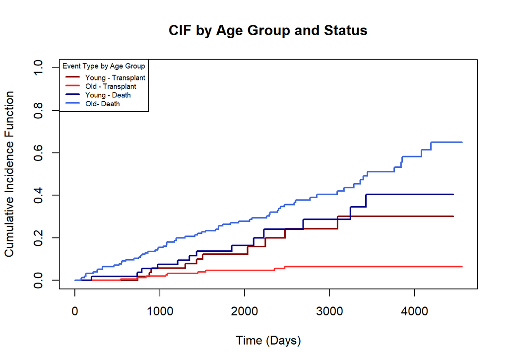

Age groups are: Young (32-40 years old) and Old (41-55). They were determined by the median age among those who received a transplant (due to low count of patients with status=1). - Like previous CIFs, Death remains the dominant event in both groups. - Older patients are more likely to die over the follow-up period. - Younger age increases the chance of transplant (even though overall transplant rates are low). The main takeaway is that age is a major factor: Older patients have higher risk of death and lower chance of transplant, whereas younger patients have lower mortality and slightly higher chance of transplant.

# Fine and Gray Model for Competing Risks

The Fine and Gray model used for competing risks by modeling the subdistribution hazard. Unlike Cox, it doesn’t censor competing events, making it better suited for estimating the effect of covariates on the probability of a specific outcome over time. In this project, death is our event of interest.

```
## Competing Risks Regression
##
## Call:
## FGR(formula = Hist(time, status) ~ factor(drug) + age_years +
##     sex + ascites + hepatomegaly + spiders + factor(edema) +
##     bili + chol + albumin + copper + alk_phos + sgot + trig +
##     platelet + protime + factor(stage), data = data_clean, cause = 2)
##
##                       coef exp(coef) se(coef)      z p-value
## factor(drug)2    -0.116105     0.890 2.19e-01 -0.529 0.60000
## age_years         0.037999     1.039 1.15e-02  3.300 0.00097
## sex              -0.301870     0.739 3.41e-01 -0.886 0.38000
## ascites           0.067348     1.070 5.06e-01  0.133 0.89000
## hepatomegaly      0.062859     1.065 2.53e-01  0.248 0.80000
## spiders           0.111232     1.118 2.75e-01  0.404 0.69000
## factor(edema)0.5  0.244741     1.277 3.48e-01  0.704 0.48000
## factor(edema)1    1.165491     3.207 5.10e-01  2.284 0.02200
## bili              0.075117     1.078 2.35e-02  3.202 0.00140
## chol              0.000359     1.000 4.10e-04  0.876 0.38000
## albumin          -0.629997     0.533 2.85e-01 -2.213 0.02700
## copper            0.001963     1.002 1.23e-03  1.597 0.11000
## alk_phos          0.000022     1.000 4.23e-05  0.522 0.60000
## sgot              0.004291     1.004 1.97e-03  2.178 0.02900
## trig             -0.000259     1.000 1.48e-03 -0.176 0.86000
## platelet          0.000652     1.001 1.31e-03  0.500 0.62000
## protime           0.320056     1.377 1.13e-01  2.840 0.00450
## factor(stage)2    1.477371     4.381 1.10e+00  1.338 0.18000
## factor(stage)3    1.671266     5.319 1.07e+00  1.564 0.12000
## factor(stage)4    2.041418     7.702 1.07e+00  1.908 0.05600
##
##                  exp(coef) exp(-coef)  2.5% 97.5%
## factor(drug)2        0.890      1.123 0.579  1.37
## age_years            1.039      0.963 1.016  1.06
## sex                  0.739      1.352 0.379  1.44
## ascites              1.070      0.935 0.396  2.89
## hepatomegaly         1.065      0.939 0.648  1.75
## spiders              1.118      0.895 0.652  1.92
## factor(edema)0.5     1.277      0.783 0.646  2.52
## factor(edema)1       3.207      0.312 1.180  8.72
## bili                 1.078      0.928 1.030  1.13
## chol                 1.000      1.000 1.000  1.00
## albumin              0.533      1.878 0.305  0.93
## copper               1.002      0.998 1.000  1.00
## alk_phos             1.000      1.000 1.000  1.00
## sgot                 1.004      0.996 1.000  1.01
## trig                 1.000      1.000 0.997  1.00
## platelet             1.001      0.999 0.998  1.00
## protime              1.377      0.726 1.104  1.72
## factor(stage)2       4.381      0.228 0.503 38.16
## factor(stage)3       5.319      0.188 0.655 43.18
## factor(stage)4       7.702      0.130 0.946 62.67
##
## Num. cases = 276
## Pseudo Log-likelihood = -473
## Pseudo likelihood ratio test = 168  on 20 df,
```

### Fine and Gray Results with Benjamini-Hochberg Adjustment for Multiple Comparisons

|  | Coefficient | Exp_Coef | Std_Error | Z_value | P_value | Adjusted_P_value |
| --- | --- | --- | --- | --- | --- | --- |
| factor(drug)2 | -1.161050e-01 | 0.8903817 | 2.194253e-01 | -0.5291323 | 0.60000 | 0.77500000 |
| age_years | 3.799884e-02 | 1.0387300 | 1.151533e-02 | 3.2998493 | 0.00097 | 0.01400000 |
| sex | -3.018696e-01 | 0.7394345 | 3.405695e-01 | -0.8863670 | 0.38000 | 0.63333333 |
| ascites | 6.734786e-02 | 1.0696675 | 5.064066e-01 | 0.1329917 | 0.89000 | 0.89000000 |
| hepatomegaly | 6.285925e-02 | 1.0648769 | 2.534312e-01 | 0.2480328 | 0.80000 | 0.88888889 |
| spiders | 1.112321e-01 | 1.1176543 | 2.752204e-01 | 0.4041564 | 0.69000 | 0.81176471 |
| factor(edema)0.5 | 2.447407e-01 | 1.2772900 | 3.475884e-01 | 0.7041106 | 0.48000 | 0.73846154 |
| factor(edema)1 | 1.165491e+00 | 3.2074990 | 5.101940e-01 | 2.2844086 | 0.02200 | 0.09666667 |
| bili | 7.511725e-02 | 1.0780105 | 2.345641e-02 | 3.2024195 | 0.00140 | 0.01400000 |
| chol | 3.592359e-04 | 1.0003593 | 4.099567e-04 | 0.8762776 | 0.38000 | 0.63333333 |

[output cut: 10 more lines]

After applying the Benjamini-Hochberg method for multiple comparisons, age in years, bili and protime are significant at the 0.05 level. Refitting fine and gray model of death as event of interest with only these variables.

### Refit Fine and Gray Model for with Selected Variables

```
## Competing Risks Regression
##
## Call:
## FGR(formula = Hist(time, status) ~ age_years + bili + protime,
##     data = data_clean, cause = 2)
##
##             coef exp(coef) se(coef)    z p-value
## age_years 0.0429      1.04   0.0105 4.08 4.4e-05
## bili      0.1336      1.14   0.0151 8.84 0.0e+00
## protime   0.2411      1.27   0.1020 2.36 1.8e-02
##
##           exp(coef) exp(-coef) 2.5% 97.5%
## age_years      1.04      0.958 1.02  1.07
## bili           1.14      0.875 1.11  1.18
## protime        1.27      0.786 1.04  1.55
##
## Num. cases = 276
## Pseudo Log-likelihood = -505
## Pseudo likelihood ratio test = 104  on 3 df,
```

### Final Model Results with Benjamini-Hochberg Adjustment for Multiple Comparisons

|  | Coefficient | Exp_Coef | Std_Error | Z_value | P_value | Adjusted_P_value |
| --- | --- | --- | --- | --- | --- | --- |
| age_years | 0.04285394 | 1.043785 | 0.01049443 | 4.083492 | 4.4e-05 | 6.6e-05 |
| bili | 0.13355382 | 1.142883 | 0.01510449 | 8.841994 | 0.0e+00 | 0.0e+00 |
| protime | 0.24110170 | 1.272650 | 0.10200875 | 2.363539 | 1.8e-02 | 1.8e-02 |

The Fine and Gray model showed strong model fit (Pseudo likelihood ratio test = 104 on 3 df). All the covariates in the final model are statistically significant after BH correction (p value < 0.05), indicating a strong fit for the model.

exp(coef) provides the subdistribution hazard ratio and shows how a covariate affects the CIF of event of interest (death), while accounting for competing risks (liver transplant). For each additional year of age, the subdistribution hazard of death increases by 4.38% with account for transplant. That means older patients are slightly more likely to die sooner, even considering the possibility of transplant. For each additional mg/dL of bilirubin, the subdistribution hazard of death increases by 14.28% with account for transplant. Higher bilirubin levels greatly raise the cumulative incidence of death. For each additional second of prothrombin time, the subdistribution hazard of death increases by 27.26%. This suggests that patients with impaired blood clotting (longer protime) are significantly more likely to die over time, even when adjusting for transplant as a competing risk.

## C-Index for Fine and Gray Model

```
## Cindex for competing risks
```

The C-index for the Fine and Gray model for death event is 0.7351078, indicating that in 73.5% of comparable patient pairs, the patient who died earlier was assigned a higher predicted risk by the mode. This indicates that the model has good discriminative ability.

## Integrated Brier Score for Fine and Gray Model

Note: We calculated the Integrated Brier Score by numerically integrating the Brier score over time using the trapezoidal rule, providing an estimate of the model’s average prediction error across the follow-up period.

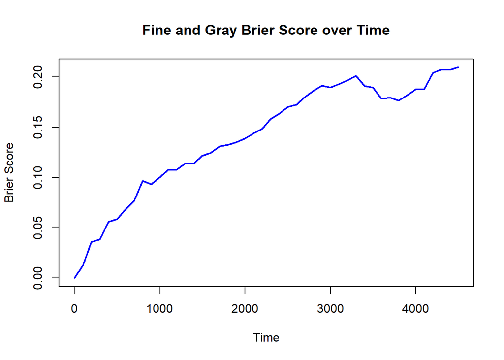

The Fine and Gray model achieved a Integrated Brier score of 0.1413131, meaning that the average prediction error survival probability is 14.13%. This indicates that the model has a good fit for the data, as lower Brier scores indicate better predictive accuracy. There’s a steady rise in Brier score as time increases, indicating that the predictive performance declines over time. Around 3000-3500 days, the score starts decreasing, which might indicate not reliable estimates or increased noise in the data.

# Random Survival Forest

A Random Survival Forest (RSF) is a method used to predict how long it takes until an event occurs (death or liver transplant). It’s an extension of Random Forest model, and is specially designed to handle time-to-event data and censored data. Useful for exploring nonlinear effects and model behavior.

## Tuning Parameters

Tuning the model with 500 trees for faster results. The final model will be based on 1000 trees and 100 split points. - Splitting criterion is logrankCR, which is suitable for competing risks models. - We tuned nodesize (terminal node size) and mtry (amount of variables to consider at each split).

```
##    nodesize mtry       err
## 1         5    1 0.4425990
## 2         5    2 0.4204432
## 3         5    3 0.4210044
## 4         5    4 0.4217005
## 5         5    6 0.4178080
## 6         5    9 0.4247423
## 7         5   13 0.4215416
## 8        10    1 0.4184098
## 9        10    2 0.4229458
## 10       10    3 0.4360493
## 11       10    4 0.4366462
## 12       10    6 0.4196328
## 13       10    9 0.4483263
## 14       15    1 0.4454448
## 15       15    2 0.4268958
## 16       15    3 0.4322337
## 17       15    4 0.4374180
## 18       15    6 0.4395897
## 19       15    9 0.4504273
## 20       20    1 0.4311900
## 21       20    2 0.4354820
## 22       20    3 0.4413320
## 23       20    4 0.4437989
## 24       20    6 0.4464861
## 25       20    9 0.4580870
```

The function ‘tune.rfsrc’ uses a greedy search algorithm based on out-of-bag (OOB) error minimization to find the optimal hyperparameters. The results show that the best mtry is 6 and the best nodesize is 5. This will results in deeper and more flexible trees (small node size), as well as more diversity among trees (low mtry).

## Final RSF Model

```
##                          Sample size: 276
##                     Number of events: 147, 18, 111
##                      Number of trees: 1000
##            Forest terminal node size: 5
##        Average no. of terminal nodes: 38.936
## No. of variables tried at each split: 6
##               Total no. of variables: 17
##        Resampling used to grow trees: swor
##     Resample size used to grow trees: 174
##                             Analysis: RSF
##                               Family: surv-CR
##                       Splitting rule: logrankCR *random*
##        Number of random split points: 100
##    (OOB) Requested performance error: 0.45466406, 0.49019608, 0.3027027
```

The final RSF model was trained with 1000 trees, 6 variables tried at each split, 5 terminal node size, and 100 random split points. OOB: 0.4546641 for transplant, 0.4901961 for death, 0.3027027 overall.

## Variables Importance

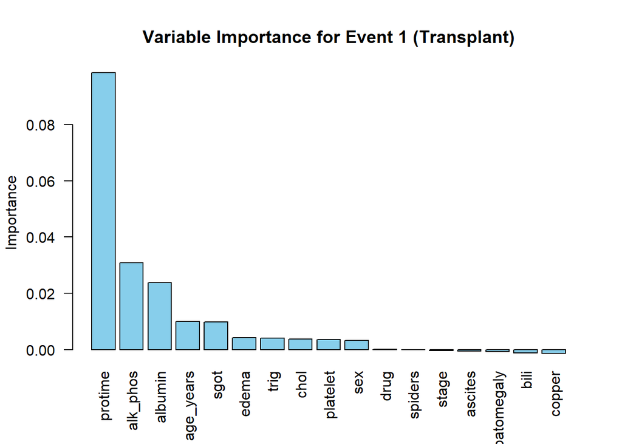

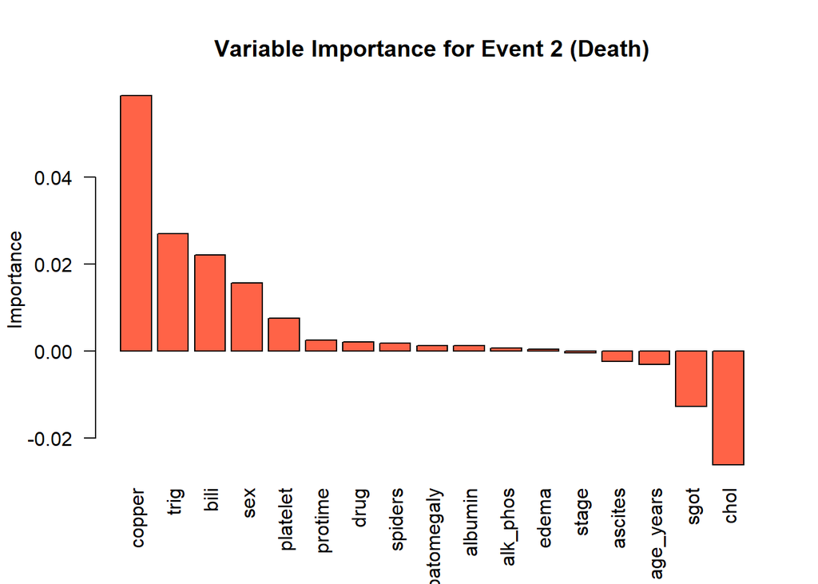

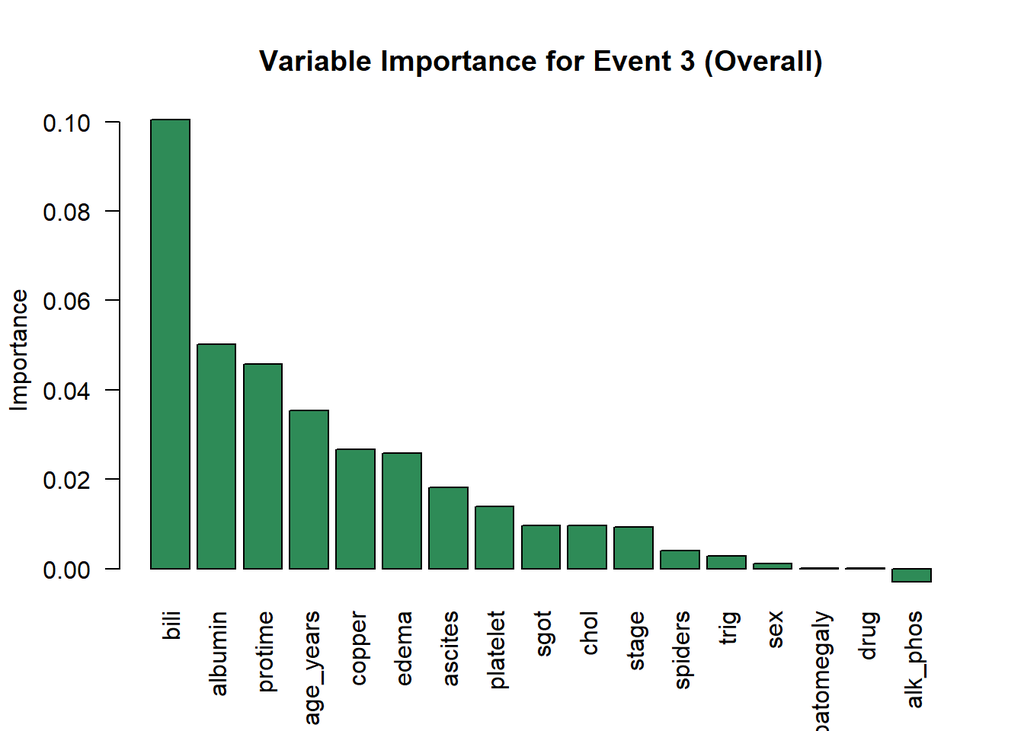

The variable importance plots show the relative importance of each covariate in predicting the different events (transplant, death, and overall).

## RSF Model for Death Event (Right Censored Model)

```
##                          Sample size: 276
##                     Number of deaths: 111
##                      Number of trees: 1000
##            Forest terminal node size: 5
##        Average no. of terminal nodes: 21.508
## No. of variables tried at each split: 6
##               Total no. of variables: 18
##        Resampling used to grow trees: swor
##     Resample size used to grow trees: 174
##                             Analysis: RSF
##                               Family: surv
##                       Splitting rule: logrank *random*
##        Number of random split points: 100
##                           (OOB) CRPS: 342.78404543
##                    (OOB) stand. CRPS: 0.08179051
##    (OOB) Requested performance error: 0.10322379
```

## Bilirubin Partial Dependence Plots

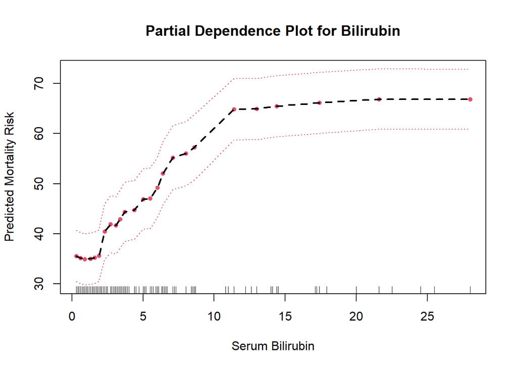

As bilirubin increases, the model predicts higher mean cumulative mortality risk. Black dashed line: Average predicted mortality across the dataset for each bilirubin value. Red bounds: 95% Confidence intervals.

## Copper Partial Dependence Plots

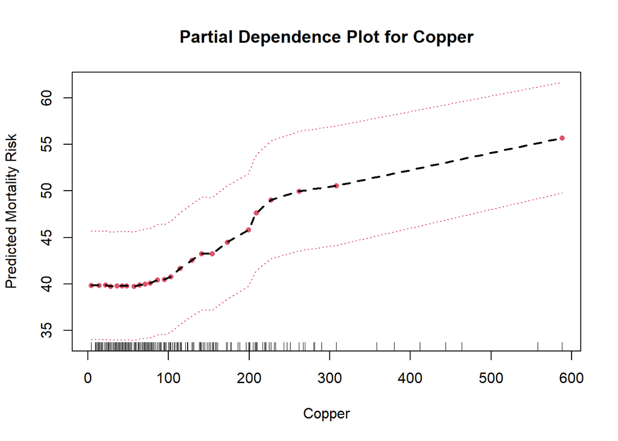

As copper increases, the model predicts higher mean cumulative mortality risk.

## Albumin Partial Dependence Plots

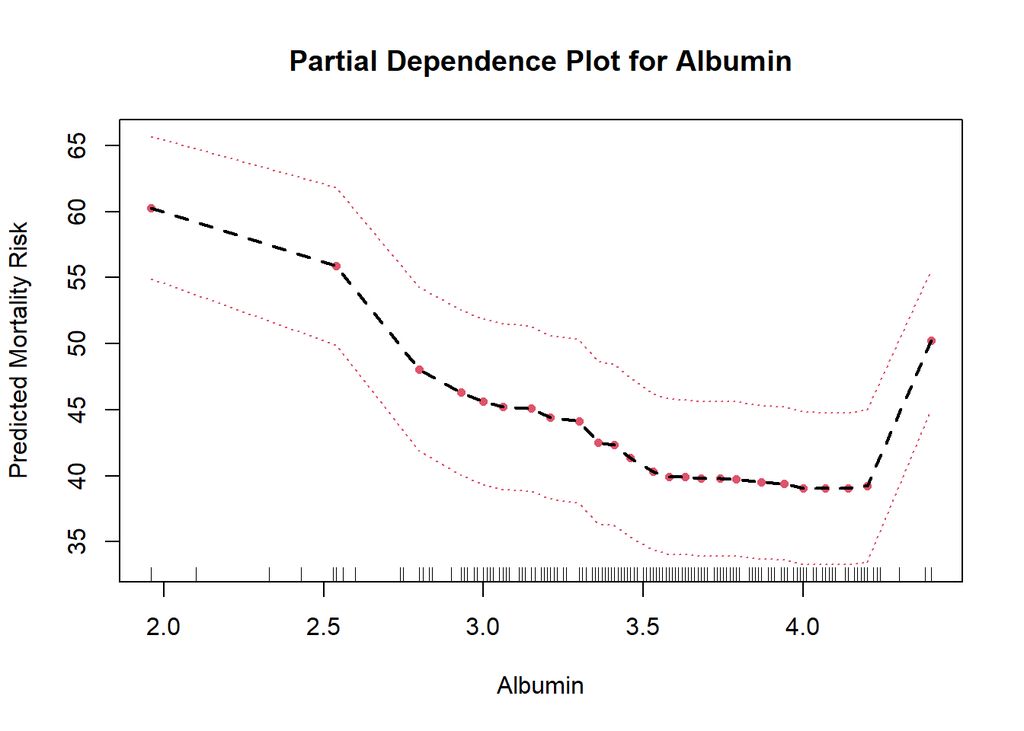

As albumin increases, the model predicts lower mean cumulative mortality risk, and gets higher for high albumin values.

## Predicted Time-Dependent ROC Plot at 3 years For Death Event

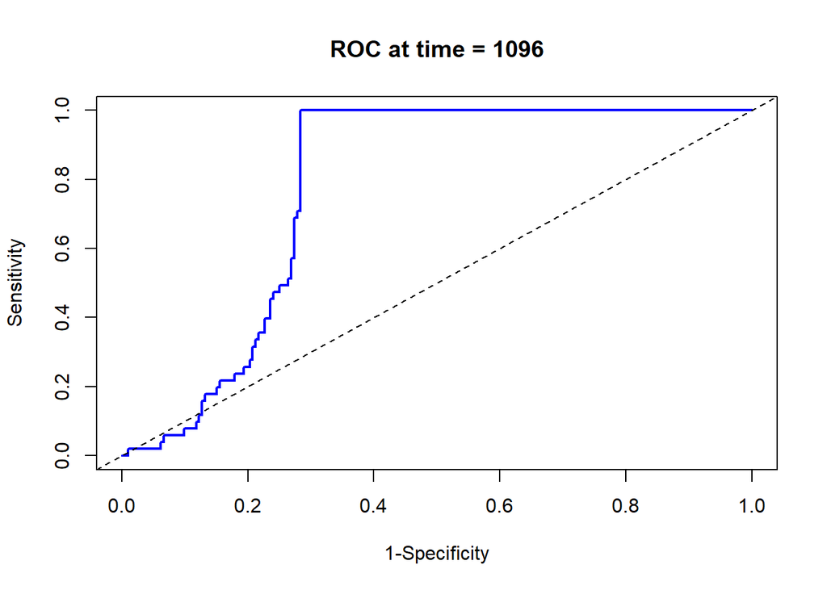

The time-dependent ROC curve at 3 years demonstrates strong discriminative performance of the model, with an AUC of 0.7754789, meaning 77.5% of the time, the model assigns a higher predicted risk to a patient who died before 3 years than to one who survived longer.

## C-Index for RSF Model for Death Event

The C-index for the RSF model for death event is 0.869197, indicating a high ability to correctly rank patients by their risk of death over time.

## Brier Score for RSF Model for Death Event

Note: We calculated the Integrated Brier Score by numerically integrating the Brier score over time using the trapezoidal rule, providing an estimate of the model’s average prediction error across the follow-up period.

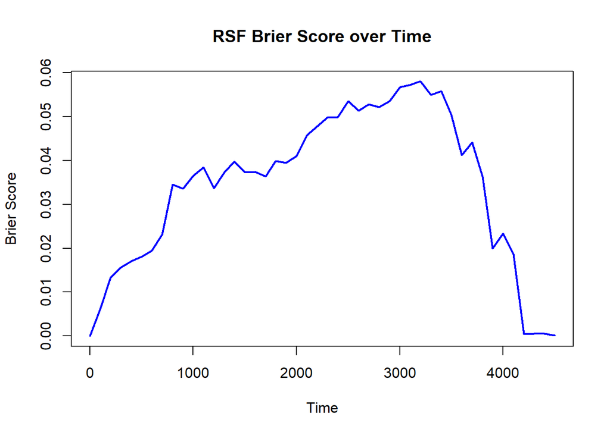

The RSF model achieved a Integrated Brier score of 0.0349547, meaning that the average prediction error survival probability is 3.5%. This indicates that the model has a good fit for the data, as lower Brier scores indicate better predictive accuracy. The RSF model’s Brier score remains consistently low across most of the time period. It increases gradually up to around 3300-3500 time units, and then drops steeply toward the end (due to low count of remaining subject, which causes scores to appear low)

# Deep Learning Survival Model - DeepHit

DeepHit is a deep-learning model for survival analysis with competing risks, mainly used for predictions. It learns the probability of each event type at each time using a neural network, without strong assumptions like traditional models. This lets it handle complex patterns in the data and give accurate estimates of the CIF. Its loss function improves both calibration and discrimination. For this model, we divided the data to train (64%), validation (16%) and test sets (20%).

Minibatch Gradient Descent is a training strategy in Deep Learning where the model updates its weights using a small subset (called a minibatch) of the full dataset on each step, rather than using the entire dataset (batch). Each epoch is split into $\frac{n_samples}{batch_size}$ mini-updates. On each step, the model: 1. Takes batch_size samples 2. Computes loss 3. Computes gradients 4. Updates the weights using an optimizer (in PyTorch, it uses Adam, which is a popular optimization algorithm that combines the benefits of AdaGrad and RMSProp). Minibatching has numerous benefits, such as faster convergence, memory efficient (since it doesn’t load all data at once), supports parallelization, etc.

1. We normalize continuous covariates (mean=0, variance=1), as neural networks are sensitive to the scale of input features. Continuous covariates we will normalize: age, bili, chol, albumin, copper, alk_phos, sgot, trig, platelet, protime. Categorical covariates we will factorize: drug (turning to binary: 0-placebo, 1-drug). Ordinal covariates we will normalize by order to [0,1] values: stage. The rest of the covariates are time (y value), status (0,1,2) or already in binary form (0/1).

2. DeepHit assumes that the time-to-event data is discrete, so we create a grid of 10 discrete time intervals $\tau_{(1)}<...<\tau_{(10)}.$

For our dataset, we have: Training set size 176 Validation set size 44 Test set size 56

Time grid: [ 0. 216. 597. 799. 1149. 1435. 1908. 2456. 3395. 4523.]

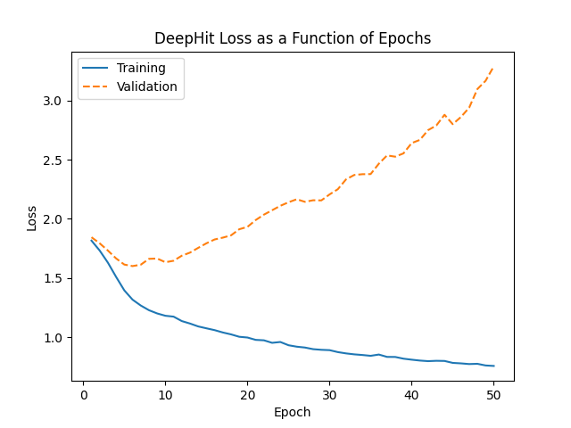

The plot shows the DeepHit loss by epochs for the training and validation sets. The training loss decreases steadily. The validation loss also decreases at a slower rate in the beginning, and then starts increasing, which might indicate overfitting for the training set. The lowest DeepHit loss for validation set is 1.6012, epoch 6.

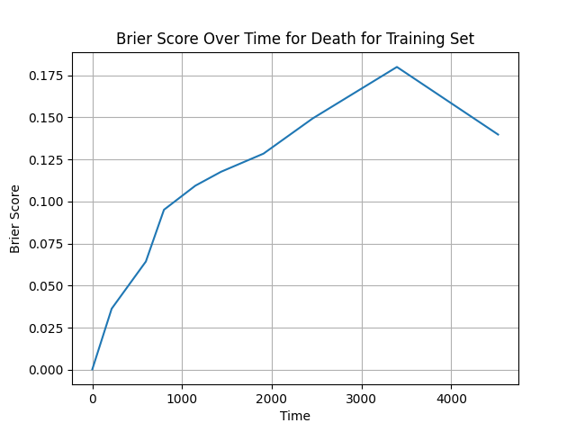

DeepHit Brier Score over Time (Training Set)

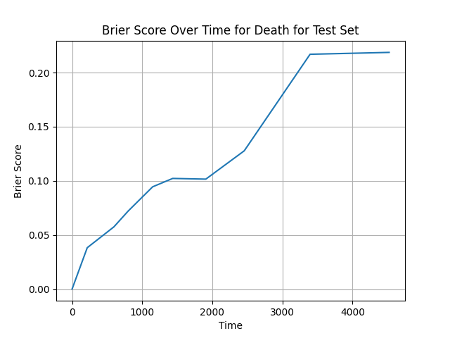

DeepHit Brier Score over Time (Test Set)

## DeepHit Results

Note 1: We calculated the Integrated Brier Score by numerically integrating the Brier score over time using Simpson’s rule, providing an estimate of the model’s average prediction error across the follow-up period. Note 2: For the C-Index, we used Antolini method, which is suitable for survival models with competing risks. Note 3: The code for the DeepHit model is in python, using PyTorch package.

# Comparing the Models

We compare the models based on several evaluation criteria: Important Variables, Concordance Index and Integrated Brier Score. These criteria are evaluated for event of death, as it is the primary event of interest in this analysis.

## Concordance Index and Integrated Brier Score

|  | Integrated_Brier | C_Index |
| --- | --- | --- |
| Cox | 0.12788141 | 0.8277393 |
| Fine and Gray | 0.14131308 | 0.7351078 |
| RSF | 0.03495465 | 0.8691970 |
| DeepHit (Training Set) | 0.13020000 | 0.7452000 |
| DeepHit (Test Set) | 0.13710000 | 0.6676000 |

# Conclusions